# Effects of Different loan listing Characteristics on Loan Original Amount

## Investigation Overview

In this investigation,I will be analysing the different loan listing Characteristics and their relationship with Loan Original Amount and prosper rating

## Dataset Overview

There are 113937 loan records in the dataset with 80 features out of which 30 important features and 84853 records will be considered for this our analysis due to their relevance in determining the amount of loan to be collected and prosper rating. Majority of the variables are numeric (float and imteger) in nature, but the variable LoanOriginationDate is in datetime after careful convertion while the remaining features are categorical in nature.

## Distribution of LoanOriginalAmount

LoanOriginalAmount has a right skewed distribution, with a lot of loan listing on the low LoanOriginalAmount end, and few on the high LoanOriginalAmount end.

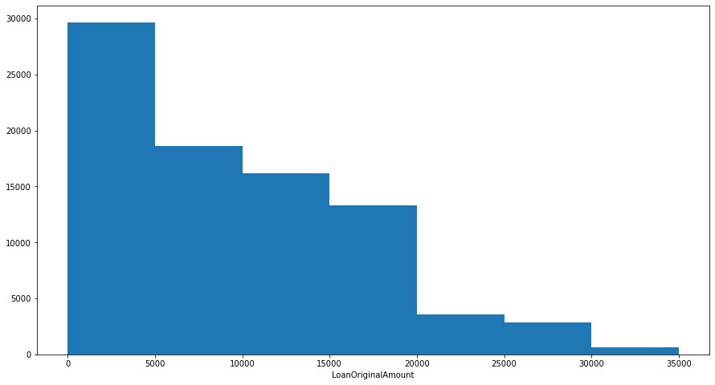

## ProsperRating vs. Average LoanOriginalAmount

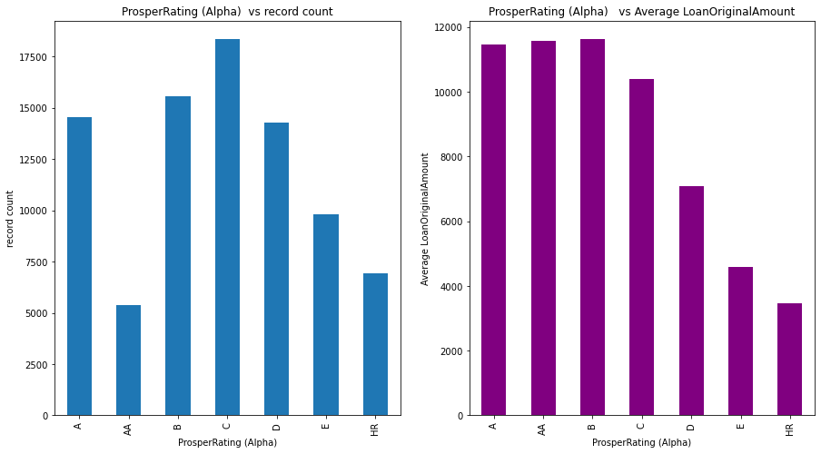

## LoanOriginatingDate vs. Average LoanOriginalAmount

from the line graph we can see that the average loan original amount keeps increasing over the years of the survey

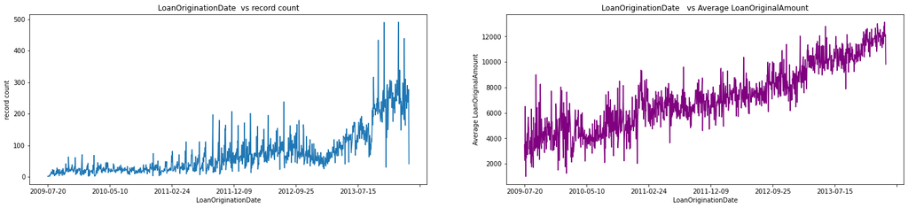

## Bivariate Exploration (Heat Map correlation)

> from the colleration heat map we can detect certain relationship

> > borrower rate and borrower APR shows strong positive correlation

> > borrower rate and Prosper rating shows strong negative correlation

> > prosper rating and loan amount shows slighty strong positive correlation

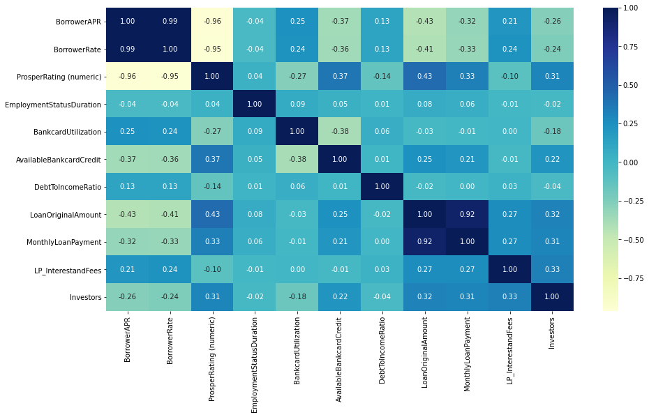

## LoanOriginatingQuarter vs. Average LoanOriginalAmount

Highest percentage of the loan listing was carried out in the 4th quarter, followed by the 1st quarter and lastly by the 2nd quarter of the year, with the 1st quarter recording the highest average loan amount for the years the survey was carried out

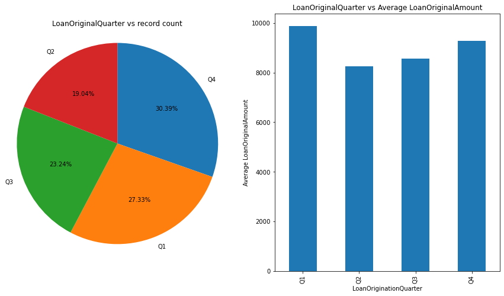

[output not shown]